# Computational Skills for Materials Science: Homework

### Task 1: Writing equations using Latex

$f(\phi_1)= \phi_1 $

### Task 2: Using python to display an image

Display the image with the following url:'https://upload.wikimedia.org/wikipedia/commons/0/0a/Ductile_fracture_upd.png' and give it the title 'Ductile Fracture' in heading 3 format by "markdown"

### Importing Modules

##### The following modules are required for the homework

*matplotlib.pyplot*

*numpy*

### Task 3: : Using python for simple calculations

##### Task 3.1

A circle has a radius of 2mm. Calculate the area of the circle and print the result in format of float to 3 places after the decimal and its unit.

##### Task 3.2

A list is given as below

```python
list_of_values=[1010,1008,1011,1009,1000,1012,1009,1013,1003,1004,1005,1000,1003,1008,1015,1016,1014,1019,1005,1002]
```

1. Calculate the average of the list above
2. Calculate the standard deviation

### Task 4: : Plotting Graphs

##### In order to view a plot within the work space of Ipython

```python
%matplotlib inline
```

A list of stress and strain values have been given below.

```python
strain = [0.0748, 0.0997, 0.0109, 0.0449, 0.0948, 0.0798, 0.0698, 0.0029, 0.0159, 0.0179, 0.0094,
        0.0499, 0.0079, 0.0099, 0.0129, 0.0848, 0.0548, 0.0139, 0.0019, 0.0089, 0.0598, 0.0648,
        0.0224, 0.0124, 0.0898, 0.0114, 0.0274, 0.0249, 0.0069, 0.0299, 0.0119, 0.0, 0.0199,
        0.0349, 0.0049, 0.0039, 0.0059, 0.0104, 0.0009, 0.0399]
stress = [1133.0, 1147.0, 1077.0, 189.0, 1122.0, 1293.0, 1100.0, 1095.0, 1171.0, 1210.0, 1339.0,
        1035.0, 1118.0, 1105.0, 1498.0, 818.0, 1475.0, 1114.0, 1110.0, 1159.0, 1407.0, 1270.0, 1247.0,
        0.0, 1430.0, 1453.0, 1544.0, 399.0, 1126.0, 1521.0, 1362.0, 1184.0, 1223.0, 1060.0, 1316.0,
        1197.0, 977.0, 1089.0, 1384.0, 609.0]
```

4.1. Sort out the values in ascending order and assign the new arrays to be **"true_strain"** and **"true_stress_1"**

4.2. Plot true_stress_1 (y-axis) against true_strain (x-axis) with a title as 'Tensile Stress-Strain Curve'

4.3. Label the y-axis as 'True Stress (MPa)' and the x-axis as 'True Strain [-]'

Another experimental data with **true_stress_2** is given below

```python
true_stress_2 = [    0.,    190.8,   402.8,   614.8,   825.8,   986.8,  1046.8,  1073.8,  1092.8,
  1106.8,  1113.8,  1119.8,  1125.8,  1131.8,  1136.8,  1141.8,  1146.8,  1151.8,
  1160.8,  1178.8,  1194.8,  1210.8,  1228.8,  1246.8,  1264.8,  1282.8,  1316.8,
  1349.8,  1382.8,  1415.8,  1448.6,  1481.6,  1513.6,  1546.6,  1579.6,  1612.6,
  1644.6,  1677.6,  1710.6,  1743.4]
```

4.4. Plot true_stress_2 (y-axis) against true_strain (x-axis) in the same plot with true_stress_1

4.5. Insert the legend of each curve at the "lower right" of the graph

### Task 5: : Manipulating 3d arrays

##### Using iteration and conditionals to create 3d arrays for each of the plot below

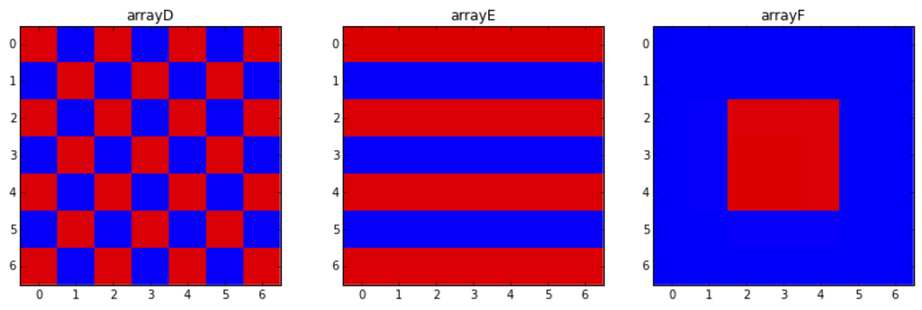

##### Instruction

1. Create a zero array with the same shape as required
2. Use iterations and conditions to allocate the color as expected

### Recap:

red = [1,0,0];

green = [0,1,0];

blue = [0,0,1];

white = [1,1,1];

black = [0,0,0];